## Climate Change vs. Energy Security

#### Erica Beattie

Canada finds itself in a strong position to ensure global energy security, but this is not without its challenges. The main issue being how to accomplish this without sacrificing our climate goals, such as the [2050 Net Zero targets](https://www.iea.org/reports/net-zero-by-2050).

Canada’s short-term focus is on increasing oil and gas production in attempt to ease the current global crisis, brought on by the Russian invasion. On the other hand, our long-term commitment is to competitive and decarbonized oil and gas. Striking a balance will be key, but according to [RBC](https://thoughtleadership.rbc.com/the-new-climate-bargain-how-canada-can-manage-energy-environmental-security/), it may come at a significant cost.

This cost could include drastic capital spending and significant amounts of greenhouse gas emissions, further contributing to [global warming](https://climate.nasa.gov/news/2865/a-degree-of-concern-why-global-temperatures-matter/).

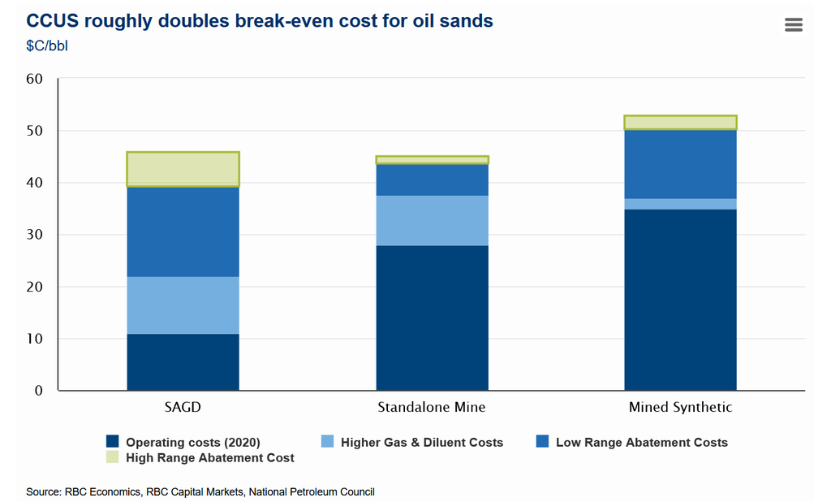

The path to energy and climate security is not a straightforward one, as there are so many factors at play. But there are numerous steps Canada can take, and is taking, to move forward. One major step would be to forge energy alliances by working with international partners, such as Europe and Asia, and create strong trade ties. This would lead to great economic opportunities for Canada. A perfect example would be for Canada to capitalize on its existing liquified natural gas projects, and export this source to Asia.